# R Essentials for Data Analysis

Research Informatics Core

Fall 2026

# 1 Day 1

**DOWNLOAD THE R SCRIPT FOR THIS WORKSHOP:**

https://wd.cri.uic.edu/R/R_exercise.R

## 1.1 Basic usage

*TIPS*

- Use Tab to auto complete
- Use up arrow to get previous command

### 1.1.1 Create a new project in R Studio

1. From *File* menu select *New Project…*
2. From **New Project** Dialog select *New Directory*

[figure not shown]

3. Select *New Project* as project type.

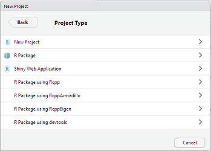

4. Give a project name, i.e. “Workshop” and click **Create Project** button.

[figure not shown]

### 1.1.2 Create a new script.

1. From the *File* menu select *New File* > *R Script*
2. Save file as “my_Rscript.R”

Write the following commands in code editor of R Studio and run them using icon **Run** in R Studio

### 1.1.3 Creating variables

Important notes:

- Assign a value using an “arrow” (`<-`) or equals (`=`). *These mean the same thing.*
  - The `<-` arrow is the “standard” in R, so we will use that.
- Basic variable types:
  - Numeric: `1`, or `2.1`, or `1.63e-5`
  - Character: `"cat"` or `"dog"`
  - Boolean: `TRUE` or `FALSE`

Look at the **Environment** panel (top right) as you run these commands: you will see the variables appear as you define them.

1. Create different type of variables, note that the name must not start with a number.
   - You can use `<-` or `=` for assignment of values.
   - For boolean values, you can use `T` or `F` as shortcuts for `TRUE` or `FALSE`

```r
a <- 100
b <- "hello"
x <- TRUE
```

2. Just type the variable name to see its value

```r
a
```

```
## [1] 100
```

3. You can see the type of variable by using `class()`

```r
class(b)
```

```
## [1] "character"
```

### 1.1.4 Multi-valued (collection) variables

We have several ways of creating collections of multiple values in a single variable.

*1-dimensional:*

- **Vector**: multiple values of the same type, e.g. `(1, 2, 3)` or `("x","y","z")`
- **List**: multiple values of different types, e.g. `(1, "cow", TRUE)`

*2-dimensional:*

- **Matrix**: table (rows by columns), all of the same type
- **Data frame**: table (rows by columns), different columns can have different types
1. Create a vector of numbers

```r
x <- c(6,5,4)
x
```

```
## [1] 6 5 4
```

2. Create a vector of character values.

```r
y <- c("mouse", "cat", "dog")
y
```

```
## [1] "mouse" "cat"   "dog"
```

3. Create a `list` of different things.
   - It can have ANY combination of objects you want.
   - In this example, the values are numeric, character, Boolean and the last element is a vector of numeric values.

```r
z <- list(4, "cat", TRUE, c(1,2))
z
```

```
## [[1]]
## [1] 4
##
## [[2]]
## [1] "cat"
##
## [[3]]
## [1] TRUE
##
## [[4]]
## [1] 1 2
```

4. Create a `matrix`.
   - We use the `nrow` parameter to tell it to create a matrix with three rows.
   - The `matrix()` function will fill in the data column-wise.
   - `1:6` is a shortcut for a vector of all numbers from 1 to 6

```r
A <- matrix(c(1:6), nrow=3)
A
```

```
##      [,1] [,2]
## [1,]    1    4
## [2,]    2    5
## [3,]    3    6
```

5. Create a `data.frame`.
   - A `data.frame` can combine different vectors of different data types but these MUST be the same length.
   - We give the `data.frame()` function vectors for each of the columns, in their column order.

```r
df <- data.frame(x ,y)
df
```

| x | y |
| --- | --- |
| 6 | mouse |
| 5 | cat |
| 4 | dog |

6. Check the size of variables:
   - `length()`: length of vector or list
   - `dim()`: number of rows and columns of a matrix or data frame
     - `nrow()` and `ncol()`: just the number of rows or columns

```r
length(x)
```

```
## [1] 3
```

```r
dim(A)
```

```
## [1] 3 2
```

```r
nrow(A)
```

```
## [1] 3
```

### 1.1.5 Basic operations

Arithmetic:

- Addition and subtraction: `1 + 2` ; `6 - 5`
- Multiplication and division: `x * y` ; `3 / 4`

Boolean:

- AND: `a & b`
- OR: `a | b`

Set membership: `%in%`

Sorting objects: using `order()`

Transpose a matrix: swap the rows and columns, `t()` function

1. Arithmetic on single values

```r
1 + 1
```

```
## [1] 2
```

```r
12/3
```

```
## [1] 4
```

2. Arithmetic on a vector or matrix
   - First we look at the current values
   - Next is element-wise addition
   - Lastly is element-wise multiplication

```r
A
```

```
##      [,1] [,2]
## [1,]    1    4
## [2,]    2    5
## [3,]    3    6
```

```r
A + A
```

```
##      [,1] [,2]
## [1,]    2    8
## [2,]    4   10
## [3,]    6   12
```

```r
A * A
```

```
##      [,1] [,2]
## [1,]    1   16
## [2,]    4   25
## [3,]    9   36
```

3. Boolean operations
   - `T` and `F` are shortcuts for `TRUE` and `FALSE`

```r
TRUE & FALSE
```

```
## [1] FALSE
```

```r
T | F
```

```
## [1] TRUE
```

4. Set membership: `%in%` operator

```r
y
```

```
## [1] "mouse" "cat"   "dog"
```

```r
"cat" %in% y
```

```
## [1] TRUE
```

```r
"kitten" %in% y
```

```
## [1] FALSE
```

5. Sorting
   - `order()` gives the natural order of the INDICES
   - Use `order()` as the selection (in `[]`) to obtain a sorted collection.

```r
y
```

```
## [1] "mouse" "cat"   "dog"
```

```r
order(y)
```

```
## [1] 2 3 1
```

```r
y[order(y)]
```

```
## [1] "cat"   "dog"   "mouse"
```

- Sort a data frame alphabetically by the second column

```r
df[ order(df[,2]), ]
```

|  | x | y |
| --- | --- | --- |
| 2 | 5 | cat |
| 3 | 4 | dog |
| 1 | 6 | mouse |

6. Transpose a matrix

```r
A
```

```
##      [,1] [,2]
## [1,]    1    4
## [2,]    2    5
## [3,]    3    6
```

```r
t(A)
```

```
##      [,1] [,2] [,3]
## [1,]    1    2    3
## [2,]    4    5    6
```

## 1.2 Combining and extracting elements/items from objects

Combine objects:

- Concatenate vectors or lists: `c(vec1 ,vec2)`, `c(list1, list2)`
- Combine matrices or data frames by column: `cbind(A, B)`
- Combine matrices or data frames by row: `rbind(A, B)`

Extracting elements/items. *Note that in R, the indexing starts at 1: `vec[1]` is the first item in a collection, `vec[2]` is the second, etc.*

- Get an element of a vector or list: `vec[1]`
  - NOTE: `list[1]` gives you a *list* with just the first element. `list[[1]]` gives you the *value* of the first item in the list.
- Get an element of a matrix or data frame: `matrix[1,2]` (row, then column)
  - Get all items from first row: `matrix[1, ]` (leave blank after the comma)
  - Get all items from first column: `matrix[, 1]` (leave blank before the comma)
- Specific to data frames:
  - `df[1]`: gives you a **data frame** with just the first column
  - `df[[1]]`: gives you a **vector** of the first column
1. Combine vectors

```r
c( c(1,2,3), 4:8 )
```

```
## [1] 1 2 3 4 5 6 7 8
```

2. Combine lists

```r
c( list("a","b"), list(1,c(2,3)) )
```

```
## [[1]]
## [1] "a"
##
## [[2]]
## [1] "b"
##
## [[3]]
## [1] 1
##
## [[4]]
## [1] 2 3
```

3. Combine matrices.
   - First by column
   - Second by row

```r
cbind(A, A)
```

```
##      [,1] [,2] [,3] [,4]
## [1,]    1    4    1    4
## [2,]    2    5    2    5
## [3,]    3    6    3    6
```

```r
rbind(A, A)
```

```
##      [,1] [,2]
## [1,]    1    4
## [2,]    2    5
## [3,]    3    6
## [4,]    1    4
## [5,]    2    5
## [6,]    3    6
```

4. Extract items from a vector
   - First, just the first element
   - Then the first two elements. We provide a vector of indices to select.

```r
x[1]
```

```
## [1] 6
```

```r
x[c(1,2)]
```

```
## [1] 6 5
```

5. Extract from a matrix
   - First, just the element in the first row and first column.
   - Then, first two rows for the first column. This will return a vector.
   - Same as previous but, return a matrix (do not simplify)
   - Lastly, first two rows with all columns

```r
A[1,1]
```

```
## [1] 1
```

```r
A[1:2, 1]
```

```
## [1] 1 2
```

```r
A[1:2, 1, drop=F]
```

```
##      [,1]
## [1,]    1
## [2,]    2
```

```r
A[1:2, ]
```

```
##      [,1] [,2]
## [1,]    1    4
## [2,]    2    5
```

6. Extract from a data frame.
   - Can use same operations as a `matrix` but, have a few special cases.
   - First will extract the first column and return a `data.frame`
   - The second will return the first column as a vector

```r
df[1]
```

| x |
| --- |
| 6 |
| 5 |
| 4 |

```r
df[[1]]
```

```
## [1] 6 5 4
```

### 1.2.1 Naming

In a vector or list, we can name our elements. In a matrix or data frame, we can name the rows and columns. **This is very useful for referencing values later.**

Names can be used in brackets instead of numbers, e.g., `vec["value1"]`. For lists and data frames you can also use `$` operator to refer to names (refers to column names for data frames).

1. Naming elements in a vector.
   - Will add names to an existing vector (`x`) using the `names()` function.
   - Then will extract the element with the name “second”.

```r
x
```

```
## [1] 6 5 4
```

```r
names(x) <- c("first","second","third")
x
```

```
##  first second  third
##      6      5      4
```

```r
x["second"]
```

```
## second
##      5
```

2. Creating a named vector

```r
newx <- c("cat"=1, "dog"=2)
newx
```

```
## cat dog
##   1   2
```

3. Assign row names and column names to a `data.frame`
   - This will add names to an existing `data.frame`
   - Can extract elements by row and/or column name.
   - For a `data.frame` we can use the `$` operator to select a column (as a vector). *NOTE*: The `$` operator only works for `list` or `data.frame` objects. This will not work for a `matrix`.

```r
rownames(df) <- c("r1","r2","r3")
colnames(df) <- c("size","animal")
df
```

|  | size | animal |
| --- | --- | --- |
| r1 | 6 | mouse |
| r2 | 5 | cat |
| r3 | 4 | dog |

```r
df["r1","animal"]
```

```
## [1] "mouse"
```

```r
df[c("r1","r3"), ]
```

|  | size | animal |
| --- | --- | --- |
| r1 | 6 | mouse |
| r3 | 4 | dog |

```r
df$animal
```

```
## [1] "mouse" "cat"   "dog"
```

### 1.2.2 Factors

A factor is a special type of vector used to store categorical information. For example, storing group metadata. Example:

- Experiment with wild-type (WT) and two different knock-outs (KO1, KO2).
- There are two replicates for each genotype, so list each value twice.

Factors are very important when we set up statistical analyses and need to define groups.

```r
f <- factor(c("WT","WT","KO1","KO1","KO2","KO2"))
f
```

```
## [1] WT  WT  KO1 KO1 KO2 KO2
## Levels: KO1 KO2 WT
```

A factor has:

- A **vector** with discrete categorical values.
  - Could be numbers or characters, but NOT measurements (continuous values). Only a specific number of unique values.
- **Levels**, which is a second vector of the possible unique values.
  - If you add to or modify the factor vector, you can only add values of the existing levels.
  - You can modify the displayed values of the vector by changing level names.
  - You can specify the order of the levels for convenience.
  - You can make it ordinal or ordered factor. This allows one to rank the levels.
1. See the possible levels of a factor **NOTE**: This is a character vector with the unique values.

```r
levels(f)
```

```
## [1] "KO1" "KO2" "WT"
```

2. Change the name of the “WT” level

```r
levels(f)[3] <- "Wild-Type"
f
```

```
## [1] Wild-Type Wild-Type KO1       KO1       KO2       KO2
## Levels: KO1 KO2 Wild-Type
```

```r
f[6] <- "KO3"
f
```

```
## [1] Wild-Type Wild-Type KO1       KO1       KO2       <NA>
## Levels: KO1 KO2 Wild-Type
```

4. Redefine the levels of `f` so “WT” is the first level.

*Copy-paste your earlier command and edit it to save time!*

```r
f <- factor(c("WT","WT","KO1","KO1","KO2","KO2"), levels=c("WT","KO1","KO2"))
f
```

```
## [1] WT  WT  KO1 KO1 KO2 KO2
## Levels: WT KO1 KO2
```

5. Create an ordinal or ordered factor.

```r
f2 <- factor(c("time1","time2","time3"), ordered=T)
f2
```

```
## [1] time1 time2 time3
## Levels: time1 < time2 < time3
```

A very common use case is to make certain columns of a data frame factors. The `data.frame` will look the same. However, one will be able to see the possible levels for the column

```r
df
```

|  | size | animal |
| --- | --- | --- |
| r1 | 6 | mouse |
| r2 | 5 | cat |
| r3 | 4 | dog |

```r
df[,2] <- factor(df[,2])
df
```

|  | size | animal |
| --- | --- | --- |
| r1 | 6 | mouse |
| r2 | 5 | cat |
| r3 | 4 | dog |

```r
df[,2]
```

```
## [1] mouse cat   dog
## Levels: cat dog mouse
```

## 1.3 Writing functions and using apply

### 1.3.1 Write a function to find the max value of a vector.

*This is just for our practice, as the max() function already exists in R.*

Note: Use indentation (tab) to make codes more human readable.

```r
get.max <- function(x){
    max <- x[1]
    for (i in x){
        if (i > max){
            max <- i
        }
    }
    return(max)
}
a <- c(23.3, 1, 3, 55, 6)
get.max(a)
```

```
## [1] 55
```

Compare with the build-in `max` function

```r
max(a)
```

```
## [1] 55
```

### 1.3.2 apply statements

For this we will use a built-in data frame in R, *mtcars*.

- *mtcars* is data extracted from the 1974 Motor Trend magazine. It has various aspects of car design and performance for 32 cars (1973-1974 models).
1. Get information on *mtcars* data set.

```r
?mtcars
```

2. Get dimensions of the *mtcars* `data.frame`

```r
dim(mtcars)
```

```
## [1] 32 11
```

3. See the first six rows

```r
head(mtcars)
```

|  | mpg | cyl | disp | hp | drat | wt | qsec | vs | am | gear | carb |
| --- | --- | --- | --- | --- | --- | --- | --- | --- | --- | --- | --- |
| Mazda RX4 | 21.0 | 6 | 160 | 110 | 3.90 | 2.620 | 16.46 | 0 | 1 | 4 | 4 |
| Mazda RX4 Wag | 21.0 | 6 | 160 | 110 | 3.90 | 2.875 | 17.02 | 0 | 1 | 4 | 4 |
| Datsun 710 | 22.8 | 4 | 108 | 93 | 3.85 | 2.320 | 18.61 | 1 | 1 | 4 | 1 |
| Hornet 4 Drive | 21.4 | 6 | 258 | 110 | 3.08 | 3.215 | 19.44 | 1 | 0 | 3 | 1 |
| Hornet Sportabout | 18.7 | 8 | 360 | 175 | 3.15 | 3.440 | 17.02 | 0 | 0 | 3 | 2 |
| Valiant | 18.1 | 6 | 225 | 105 | 2.76 | 3.460 | 20.22 | 1 | 0 | 3 | 1 |

4. Use an `apply` function to find the max value for each feature (column)

```r
apply(mtcars, 2, max)
```

```
##     mpg     cyl    disp      hp    drat      wt    qsec      vs      am    gear
##  33.900   8.000 472.000 335.000   4.930   5.424  22.900   1.000   1.000   5.000
##    carb
##   8.000
```

5. The `tapply` function will apply the function across the values (first argument) based on the INDEX groups (second argument). In this example, we will compute the mean mpg separately for each cylinder (`cyl`) count of the cars.

```r
tapply(mtcars$mpg, mtcars$cyl, mean)
```

```
##        4        6        8
## 26.66364 19.74286 15.10000
```

6. The `sapply` and `lapply` functions are similar. Both run a function across elements in a vector or list.
   - `lapply` will always return a list matching the input data.
   - `sapply` will attempt to simplify the results, returning a vector, matrix, or data frame if it can.

This command will count how many cars have each number of cylinders: * First we will get the cylinder counts and sort them * Then we will use the cylinder counts as the input data

```r
# get the cylinders
cyls <- unique(mtcars$cyl)
cyls
```

```
## [1] 6 4 8
```

```r
cyls <- cyls[order(cyls)]
cyls
```

```
## [1] 4 6 8
```

`lapply` will return a list:

```r
lapply(cyls, function (x) sum(mtcars$cyl==x))
```

```
## [[1]]
## [1] 11
##
## [[2]]
## [1] 7
##
## [[3]]
## [1] 14
```

Note we are defining our own function inside the apply statement.

`sapply` will return a vector:

```r
sapply(cyls, function (x) sum(mtcars$cyl==x))
```

```
## [1] 11  7 14
```

**NOTE**: You could also use `table()` for the last example, but we are using this to show how the different apply statements work in R.

## 1.4 Read and write a file

1. Read the file https://wd.cri.uic.edu/R/birth_weight.txt into a data frame
2. Sort the data frame by mother’s age, and write to a new file
- Data frame columns
  - bwt: baby’s birth weight in ounce (low bwt: < 88 ounces)
  - smoke: 0 - mother is not a smoker, 1 - smoker
  - parity: 0 - child first born, 1 - otherwise
  - gestation: length of pregnancy in days
  - age: mother’s age in years
  - height: mother’s height in inches
  - weight: mother’s pregnancy weight in pounds

```r
bw_data  <- read.delim("https://wd.cri.uic.edu/R/birth_weight.txt")
head(bw_data)
```

|  | bwt | gestation | parity | age | height | weight | smoke |
| --- | --- | --- | --- | --- | --- | --- | --- |
| 1 | 120 | 284 | 0 | 27 | 62 | 100 | 0 |
| 2 | 113 | 282 | 0 | 33 | 64 | 135 | 0 |
| 3 | 128 | 279 | 0 | 28 | 64 | 115 | 1 |
| 4 | 108 | 282 | 0 | 23 | 67 | 125 | 1 |
| 5 | 136 | 286 | 0 | 25 | 62 | 93 | 0 |
| 6 | 138 | 244 | 0 | 33 | 62 | 178 | 0 |

```r
data_ordered_by_age <- bw_data[order(bw_data$age), ]
head(data_ordered_by_age)
```

|  | bwt | gestation | parity | age | height | weight | smoke |
| --- | --- | --- | --- | --- | --- | --- | --- |
| 470 | 114 | 283 | 1 | 15 | 64 | 117 | 1 |
| 400 | 120 | 271 | 1 | 17 | 64 | 142 | 1 |
| 429 | 123 | 323 | 1 | 17 | 64 | 140 | 0 |
| 537 | 141 | 284 | 1 | 17 | 64 | 105 | 0 |
| 561 | 144 | 289 | 1 | 17 | 69 | 130 | 1 |
| 812 | 124 | 284 | 1 | 17 | 62 | 112 | 0 |

```r
write.table(data_ordered_by_age,"birth_weight_ordered_by_age.txt",sep="\t",
   quote=F,row.names=F)
```

## 1.5 Install CRAN and Bioconductor packages

### 1.5.1 Install CRAN package: “tidyverse”

If you are asked for a CRAN mirror site, please select one which is close to your location: e.g. “USA (IN)” Tidyverse is a collection of packages, including tidyr, dplyr, and ggplot2. Technically each of these are *dependencies* for the tidyverse package, and so will get installed also.

1. Install the package. *You only need to do this ONCE!*

```r
install.packages("tidyverse")
```

2. Load the libraries. *You need to do this when you start R and are going to use the libraries.*

```r
library(tidyr)
library(dplyr)
library(ggplot2)
```

### 1.5.2 Install Bioconductor package: “ComplexHeatmap”

```r
install.packages("BiocManager")
BiocManager::install("ComplexHeatmap", update=F)
library(ComplexHeatmap)
```

### 1.5.3 *TAKE-HOME:* How to check which packages are already installed

In R Studio you can select **Packages** tab in lower right pane to view all installed packages.

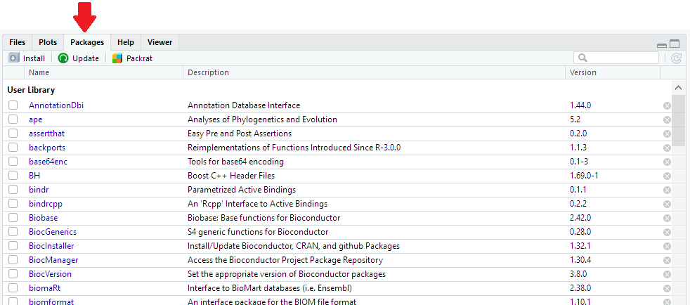

Also possible to list via R command.

1. List all install packages

```r
installed.packages()
```

2. Check if select packages are installed.

```r
c("ggplot2", "ComplexHeatmap") %in% rownames(installed.packages())
```

```
## [1] FALSE FALSE
```

## 1.6 Cleaning and transforming a sample dataset

For this exercise, we will perform some data manipulation on the *mtcars* data.

**NOTE:** Pipes (`%>%`) to `head()` are just so that we see the first 6 lines of each output.

### 1.6.1 Initial setup

- Load “tidyverse”

```r
library(tidyverse)
```

- Take a quick peek at the data.

```r
head(mtcars)
```

|  | mpg | cyl | disp | hp | drat | wt | qsec | vs | am | gear | carb |
| --- | --- | --- | --- | --- | --- | --- | --- | --- | --- | --- | --- |
| Mazda RX4 | 21.0 | 6 | 160 | 110 | 3.90 | 2.620 | 16.46 | 0 | 1 | 4 | 4 |
| Mazda RX4 Wag | 21.0 | 6 | 160 | 110 | 3.90 | 2.875 | 17.02 | 0 | 1 | 4 | 4 |
| Datsun 710 | 22.8 | 4 | 108 | 93 | 3.85 | 2.320 | 18.61 | 1 | 1 | 4 | 1 |
| Hornet 4 Drive | 21.4 | 6 | 258 | 110 | 3.08 | 3.215 | 19.44 | 1 | 0 | 3 | 1 |
| Hornet Sportabout | 18.7 | 8 | 360 | 175 | 3.15 | 3.440 | 17.02 | 0 | 0 | 3 | 2 |
| Valiant | 18.1 | 6 | 225 | 105 | 2.76 | 3.460 | 20.22 | 1 | 0 | 3 | 1 |

- Before any of the examples, we will move car names, i.e. the row.names, to a column named “car”

```r
data <- mtcars %>%
  rownames_to_column(var="car")
head(data)
```

|  | car | mpg | cyl | disp | hp | drat | wt | qsec | vs | am | gear | carb |
| --- | --- | --- | --- | --- | --- | --- | --- | --- | --- | --- | --- | --- |
| 1 | Mazda RX4 | 21.0 | 6 | 160 | 110 | 3.90 | 2.620 | 16.46 | 0 | 1 | 4 | 4 |
| 2 | Mazda RX4 Wag | 21.0 | 6 | 160 | 110 | 3.90 | 2.875 | 17.02 | 0 | 1 | 4 | 4 |
| 3 | Datsun 710 | 22.8 | 4 | 108 | 93 | 3.85 | 2.320 | 18.61 | 1 | 1 | 4 | 1 |
| 4 | Hornet 4 Drive | 21.4 | 6 | 258 | 110 | 3.08 | 3.215 | 19.44 | 1 | 0 | 3 | 1 |
| 5 | Hornet Sportabout | 18.7 | 8 | 360 | 175 | 3.15 | 3.440 | 17.02 | 0 | 0 | 3 | 2 |
| 6 | Valiant | 18.1 | 6 | 225 | 105 | 2.76 | 3.460 | 20.22 | 1 | 0 | 3 | 1 |

### 1.6.2 Examples

1. Select only mpg, cyl, and hp and pipe to head() at the end to see the first few lines

```r
data %>%
  select(car, mpg, cyl, hp) %>% head()
```

|  | car | mpg | cyl | hp |
| --- | --- | --- | --- | --- |
| 1 | Mazda RX4 | 21.0 | 6 | 110 |
| 2 | Mazda RX4 Wag | 21.0 | 6 | 110 |
| 3 | Datsun 710 | 22.8 | 4 | 93 |
| 4 | Hornet 4 Drive | 21.4 | 6 | 110 |
| 5 | Hornet Sportabout | 18.7 | 8 | 175 |
| 6 | Valiant | 18.1 | 6 | 105 |

2. Filter cars with mpg greater than 25

```r
data %>%
  filter(mpg > 25) %>% head()
```

|  | car | mpg | cyl | disp | hp | drat | wt | qsec | vs | am | gear | carb |
| --- | --- | --- | --- | --- | --- | --- | --- | --- | --- | --- | --- | --- |
| 1 | Fiat 128 | 32.4 | 4 | 78.7 | 66 | 4.08 | 2.200 | 19.47 | 1 | 1 | 4 | 1 |
| 2 | Honda Civic | 30.4 | 4 | 75.7 | 52 | 4.93 | 1.615 | 18.52 | 1 | 1 | 4 | 2 |
| 3 | Toyota Corolla | 33.9 | 4 | 71.1 | 65 | 4.22 | 1.835 | 19.90 | 1 | 1 | 4 | 1 |
| 4 | Fiat X1-9 | 27.3 | 4 | 79.0 | 66 | 4.08 | 1.935 | 18.90 | 1 | 1 | 4 | 1 |
| 5 | Porsche 914-2 | 26.0 | 4 | 120.3 | 91 | 4.43 | 2.140 | 16.70 | 0 | 1 | 5 | 2 |
| 6 | Lotus Europa | 30.4 | 4 | 95.1 | 113 | 3.77 | 1.513 | 16.90 | 1 | 1 | 5 | 2 |

3. Create a new variable (column) called *power_to_weight* using `mutate` function.

```r
data %>%
  mutate(power_to_weight=hp / wt) %>% head()
```

|  | car | mpg | cyl | disp | hp | drat | wt | qsec | vs | am | gear | carb | power_to_weight |
| --- | --- | --- | --- | --- | --- | --- | --- | --- | --- | --- | --- | --- | --- |
| 1 | Mazda RX4 | 21.0 | 6 | 160 | 110 | 3.90 | 2.620 | 16.46 | 0 | 1 | 4 | 4 | 41.98473 |
| 2 | Mazda RX4 Wag | 21.0 | 6 | 160 | 110 | 3.90 | 2.875 | 17.02 | 0 | 1 | 4 | 4 | 38.26087 |
| 3 | Datsun 710 | 22.8 | 4 | 108 | 93 | 3.85 | 2.320 | 18.61 | 1 | 1 | 4 | 1 | 40.08621 |
| 4 | Hornet 4 Drive | 21.4 | 6 | 258 | 110 | 3.08 | 3.215 | 19.44 | 1 | 0 | 3 | 1 | 34.21462 |
| 5 | Hornet Sportabout | 18.7 | 8 | 360 | 175 | 3.15 | 3.440 | 17.02 | 0 | 0 | 3 | 2 | 50.87209 |
| 6 | Valiant | 18.1 | 6 | 225 | 105 | 2.76 | 3.460 | 20.22 | 1 | 0 | 3 | 1 | 30.34682 |

4. Average mpg by number of cylinders.
- The `group_by` function will group the data based on the column(s) given
- The `summarize` function will then apply function(s) on the grouped data

```r
data %>%
  group_by(cyl) %>%
  summarise(mean_mpg=mean(mpg))
```

| cyl | mean_mpg |
| --- | --- |
| 4 | 26.66364 |
| 6 | 19.74286 |
| 8 | 15.10000 |

5. Count cars per gear group

```r
data %>%
  count(gear)
```

| gear | n |
| --- | --- |
| 3 | 15 |
| 4 | 12 |
| 5 | 5 |

6. Pivot mpg, hp, and wt into long format.
- We will just select the car, mpg, hp, and wt columns.
- `cols` list the columns to pivot. All other columns will be copied on each row.
- `names_to` will specify the name of the column in the long format that will have the original column names.
- `values_to` will specify the name of the column in the long format that will have the values.
- *NOTE*: The `pivot_longer` function will return a `tibble` object which is a more flexible `data.frame`. Showing a `tibble` will only show the first few rows and we don’t need to use head()

```r
data_long <- select(data, c(car, mpg, hp, wt)) %>%
  pivot_longer(cols=c(mpg, hp, wt),
               names_to="variable",
               values_to="value")
data_long
```

| car | variable | value |
| --- | --- | --- |
| Mazda RX4 | mpg | 21.000 |
| Mazda RX4 | hp | 110.000 |
| Mazda RX4 | wt | 2.620 |
| Mazda RX4 Wag | mpg | 21.000 |
| Mazda RX4 Wag | hp | 110.000 |
| Mazda RX4 Wag | wt | 2.875 |
| Datsun 710 | mpg | 22.800 |
| Datsun 710 | hp | 93.000 |
| Datsun 710 | wt | 2.320 |
| Hornet 4 Drive | mpg | 21.400 |

[output cut: 86 more lines]

7. Pivot back to wide format
   - `names_from` specifies the column to use as column names in the wide format
   - `values_from` specifies the column to use as the values to put in the pivoted columns.
   - All other columns will just appear as is in each row.

```r
data_long %>%
  pivot_wider(names_from=variable, values_from=value)
```

| car | mpg | hp | wt |
| --- | --- | --- | --- |
| Mazda RX4 | 21.0 | 110 | 2.620 |
| Mazda RX4 Wag | 21.0 | 110 | 2.875 |
| Datsun 710 | 22.8 | 93 | 2.320 |
| Hornet 4 Drive | 21.4 | 110 | 3.215 |
| Hornet Sportabout | 18.7 | 175 | 3.440 |
| Valiant | 18.1 | 105 | 3.460 |
| Duster 360 | 14.3 | 245 | 3.570 |
| Merc 240D | 24.4 | 62 | 3.190 |
| Merc 230 | 22.8 | 95 | 3.150 |
| Merc 280 | 19.2 | 123 | 3.440 |

[output cut: 22 more lines]

### 1.6.3 *TAKE-HOME:* Additional examples

8. Rename columns for clarity

```r
data %>%
  rename(miles_per_gallon=mpg,
         horsepower=hp) %>% head()
```

|  | car | miles_per_gallon | cyl | disp | horsepower | drat | wt | qsec | vs | am | gear | carb |
| --- | --- | --- | --- | --- | --- | --- | --- | --- | --- | --- | --- | --- |
| 1 | Mazda RX4 | 21.0 | 6 | 160 | 110 | 3.90 | 2.620 | 16.46 | 0 | 1 | 4 | 4 |
| 2 | Mazda RX4 Wag | 21.0 | 6 | 160 | 110 | 3.90 | 2.875 | 17.02 | 0 | 1 | 4 | 4 |
| 3 | Datsun 710 | 22.8 | 4 | 108 | 93 | 3.85 | 2.320 | 18.61 | 1 | 1 | 4 | 1 |
| 4 | Hornet 4 Drive | 21.4 | 6 | 258 | 110 | 3.08 | 3.215 | 19.44 | 1 | 0 | 3 | 1 |
| 5 | Hornet Sportabout | 18.7 | 8 | 360 | 175 | 3.15 | 3.440 | 17.02 | 0 | 0 | 3 | 2 |
| 6 | Valiant | 18.1 | 6 | 225 | 105 | 2.76 | 3.460 | 20.22 | 1 | 0 | 3 | 1 |

9. Filter cars with 4 or 6 cylinders

```r
data %>%
  filter(cyl %in% c(4, 6)) %>% head()
```

|  | car | mpg | cyl | disp | hp | drat | wt | qsec | vs | am | gear | carb |
| --- | --- | --- | --- | --- | --- | --- | --- | --- | --- | --- | --- | --- |
| 1 | Mazda RX4 | 21.0 | 6 | 160.0 | 110 | 3.90 | 2.620 | 16.46 | 0 | 1 | 4 | 4 |
| 2 | Mazda RX4 Wag | 21.0 | 6 | 160.0 | 110 | 3.90 | 2.875 | 17.02 | 0 | 1 | 4 | 4 |
| 3 | Datsun 710 | 22.8 | 4 | 108.0 | 93 | 3.85 | 2.320 | 18.61 | 1 | 1 | 4 | 1 |
| 4 | Hornet 4 Drive | 21.4 | 6 | 258.0 | 110 | 3.08 | 3.215 | 19.44 | 1 | 0 | 3 | 1 |
| 5 | Valiant | 18.1 | 6 | 225.0 | 105 | 2.76 | 3.460 | 20.22 | 1 | 0 | 3 | 1 |
| 6 | Merc 240D | 24.4 | 4 | 146.7 | 62 | 3.69 | 3.190 | 20.00 | 1 | 0 | 4 | 2 |

10. Use `cut` to categorize cars by engine size
- The breaks are from 0 to 150, 150 to 300, and greater than or equal to 300
  - The labels set the labels for the factor
  - When `right` is set to FALSE, then the interval will be closed on the left (include the lower number) and open on the right (excludes the right number)

```r
data %>%
  mutate(engine_size=cut(disp, breaks=c(0, 150, 300, Inf),
                           labels=c("small", "medium", "large"),
                           right=F)) %>% head()
```

|  | car | mpg | cyl | disp | hp | drat | wt | qsec | vs | am | gear | carb | engine_size |
| --- | --- | --- | --- | --- | --- | --- | --- | --- | --- | --- | --- | --- | --- |
| 1 | Mazda RX4 | 21.0 | 6 | 160 | 110 | 3.90 | 2.620 | 16.46 | 0 | 1 | 4 | 4 | medium |
| 2 | Mazda RX4 Wag | 21.0 | 6 | 160 | 110 | 3.90 | 2.875 | 17.02 | 0 | 1 | 4 | 4 | medium |
| 3 | Datsun 710 | 22.8 | 4 | 108 | 93 | 3.85 | 2.320 | 18.61 | 1 | 1 | 4 | 1 | small |
| 4 | Hornet 4 Drive | 21.4 | 6 | 258 | 110 | 3.08 | 3.215 | 19.44 | 1 | 0 | 3 | 1 | medium |
| 5 | Hornet Sportabout | 18.7 | 8 | 360 | 175 | 3.15 | 3.440 | 17.02 | 0 | 0 | 3 | 2 | large |
| 6 | Valiant | 18.1 | 6 | 225 | 105 | 2.76 | 3.460 | 20.22 | 1 | 0 | 3 | 1 | medium |

11. Introduce some NA values

```r
data_with_na <- data %>%
  mutate(mpg=replace(mpg, mpg < 20, NA))
head(data_with_na)
```

|  | car | mpg | cyl | disp | hp | drat | wt | qsec | vs | am | gear | carb |
| --- | --- | --- | --- | --- | --- | --- | --- | --- | --- | --- | --- | --- |
| 1 | Mazda RX4 | 21.0 | 6 | 160 | 110 | 3.90 | 2.620 | 16.46 | 0 | 1 | 4 | 4 |
| 2 | Mazda RX4 Wag | 21.0 | 6 | 160 | 110 | 3.90 | 2.875 | 17.02 | 0 | 1 | 4 | 4 |
| 3 | Datsun 710 | 22.8 | 4 | 108 | 93 | 3.85 | 2.320 | 18.61 | 1 | 1 | 4 | 1 |
| 4 | Hornet 4 Drive | 21.4 | 6 | 258 | 110 | 3.08 | 3.215 | 19.44 | 1 | 0 | 3 | 1 |
| 5 | Hornet Sportabout | NA | 8 | 360 | 175 | 3.15 | 3.440 | 17.02 | 0 | 0 | 3 | 2 |
| 6 | Valiant | NA | 6 | 225 | 105 | 2.76 | 3.460 | 20.22 | 1 | 0 | 3 | 1 |

12. Drop rows with NA

```r
data_with_na %>%
  drop_na() %>% head()
```

|  | car | mpg | cyl | disp | hp | drat | wt | qsec | vs | am | gear | carb |
| --- | --- | --- | --- | --- | --- | --- | --- | --- | --- | --- | --- | --- |
| 1 | Mazda RX4 | 21.0 | 6 | 160.0 | 110 | 3.90 | 2.620 | 16.46 | 0 | 1 | 4 | 4 |
| 2 | Mazda RX4 Wag | 21.0 | 6 | 160.0 | 110 | 3.90 | 2.875 | 17.02 | 0 | 1 | 4 | 4 |
| 3 | Datsun 710 | 22.8 | 4 | 108.0 | 93 | 3.85 | 2.320 | 18.61 | 1 | 1 | 4 | 1 |
| 4 | Hornet 4 Drive | 21.4 | 6 | 258.0 | 110 | 3.08 | 3.215 | 19.44 | 1 | 0 | 3 | 1 |
| 5 | Merc 240D | 24.4 | 4 | 146.7 | 62 | 3.69 | 3.190 | 20.00 | 1 | 0 | 4 | 2 |
| 6 | Merc 230 | 22.8 | 4 | 140.8 | 95 | 3.92 | 3.150 | 22.90 | 1 | 0 | 4 | 2 |

13. Replace NA with a fixed value

```r
data_with_na %>%
  replace_na(list(mpg=0)) %>% head()
```

|  | car | mpg | cyl | disp | hp | drat | wt | qsec | vs | am | gear | carb |
| --- | --- | --- | --- | --- | --- | --- | --- | --- | --- | --- | --- | --- |
| 1 | Mazda RX4 | 21.0 | 6 | 160 | 110 | 3.90 | 2.620 | 16.46 | 0 | 1 | 4 | 4 |
| 2 | Mazda RX4 Wag | 21.0 | 6 | 160 | 110 | 3.90 | 2.875 | 17.02 | 0 | 1 | 4 | 4 |
| 3 | Datsun 710 | 22.8 | 4 | 108 | 93 | 3.85 | 2.320 | 18.61 | 1 | 1 | 4 | 1 |
| 4 | Hornet 4 Drive | 21.4 | 6 | 258 | 110 | 3.08 | 3.215 | 19.44 | 1 | 0 | 3 | 1 |
| 5 | Hornet Sportabout | 0.0 | 8 | 360 | 175 | 3.15 | 3.440 | 17.02 | 0 | 0 | 3 | 2 |
| 6 | Valiant | 0.0 | 6 | 225 | 105 | 2.76 | 3.460 | 20.22 | 1 | 0 | 3 | 1 |

# 2 Day 2

## 2.1 Data Visualization

### 2.1.1 Data set

Read in the data for this exercise. This is a table of cell metadata and selected gene expression levels from a single-cell RNA-seq project. The columns in this table are:

- UMIs: total UMI (unique read) count per cell.
- Genes: number of genes expressed.
- Genotype: WT or KO, 2 genotypes profiled in this experiment.
- Batch: A or B, 2 replicate captures collected in this experiment.
- PercentMT: Fraction of reads mapping to mitochondrial genes. Higher levels can indicate issues with cell viability. For this data set, cells with % MT > 15% have already been filtered out.
- HasTCR: Whether or not this cell expressed a TCR, based on a separate TCR library collected for these samples.
- Cluster: cluster assignment from analysis.
- UMAP_1 and UMAP_2: UMAP coordinates for each cell.
- Log-scaled normalized gene expression levels for several genes of interest.
1. Load the data from the URL

```r
sc <- read.delim("http://wd.cri.uic.edu/R/scRNA_cells.txt", row.names=1)
```

2. Convert the Cluster column to a factor

```r
sc$Cluster <- factor(sc$Cluster)
head(sc)
```

|  | UMIs | Genes | Genotype | Batch | PercentMT | HasTCR | Cluster | UMAP_1 | UMAP_2 | Foxp3 | Ccr2 | Cxcr6 | Tcf7 | Ccr7 | Cxcr5 | Mki67 | Ccnb2 |
| --- | --- | --- | --- | --- | --- | --- | --- | --- | --- | --- | --- | --- | --- | --- | --- | --- | --- |
| cell1 | 16247 | 3365 | KO | A | 1.2002216 | TRUE | 0 | 1.5128867 | -5.458644 | 0 | 0.4796434 | 0.0000000 | 0.000000 | 0.000000 | 0 | 1.4054819 | 1.546070 |
| cell2 | 25246 | 4387 | WT | A | 1.3665531 | TRUE | 0 | 1.8861911 | -4.829608 | 0 | 0.0000000 | 0.9494970 | 1.092095 | 2.555914 | 0 | 0.3336843 | 1.216873 |
| cell3 | 17478 | 3537 | KO | A | 0.8410573 | TRUE | 0 | 2.1878874 | -5.429768 | 0 | 0.0000000 | 0.4524427 | 0.000000 | 0.000000 | 0 | 1.9053081 | 1.718684 |
| cell4 | 6263 | 2096 | KO | A | 1.9958486 | TRUE | 0 | 1.1611621 | -5.635682 | 0 | 0.9542333 | 0.9542333 | 0.000000 | 0.000000 | 0 | 2.1953778 | 1.756139 |
| cell5 | 18282 | 3954 | KO | A | 1.3182365 | TRUE | 0 | 3.1840550 | -5.973042 | 0 | 0.9711419 | 0.7390628 | 0.000000 | 0.000000 | 0 | 1.3177292 | 1.574619 |
| cell6 | 22809 | 4290 | KO | A | 0.8899996 | TRUE | 0 | 0.6799762 | -6.635254 | 0 | 0.0000000 | 1.5057177 | 0.000000 | 0.000000 | 0 | 2.0250317 | 1.683475 |

### 2.1.2 Scatterplots

We will make various versions of a UMAP plot.

**Using base R**

1. Basic scatter plot

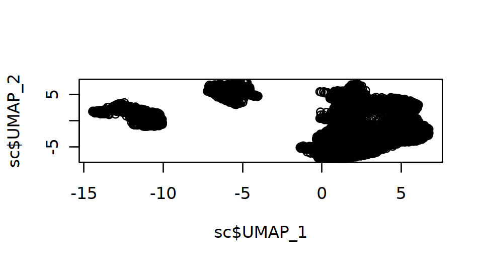

```r
plot(sc$UMAP_1, sc$UMAP_2)
```

2. Colored by cluster - this is kind of clunky
   - We are using factors as a shortcut to make unique colors for the clusters:
     - Make a factor of the cluster assignments.
     - Rename the factor levels as color names (RGB codes). The `rainbow` function gives an even spacing of colors across the rainbow for a given number of colors.

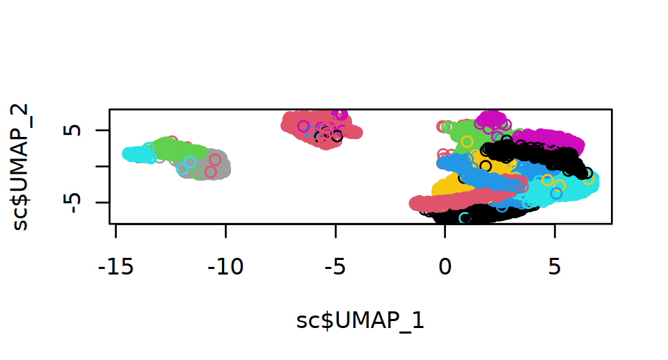

```r
cell_colors <- factor(sc$Cluster)
levels(cell_colors) <- rainbow(length(levels(cell_colors)))
plot(sc$UMAP_1, sc$UMAP_2, col=cell_colors)
```

It would be even better to add a legend. This is possible in base R plots, but much easier with ggplot2.

**Using ggplot2**

ggplot2 makes it *much* easier to add more features to our plot, like automatically coloring dots based on a categorical label and adding a legend.

1. Load the ggplot2 library

```r
library(ggplot2)
```

2. Make the basic scatter plot (`geom_point`) using the the values from the columns *UMAP_1* and *UMAP_2* as the `x` and `y` coordinates and color by the values in the column *Cluster*

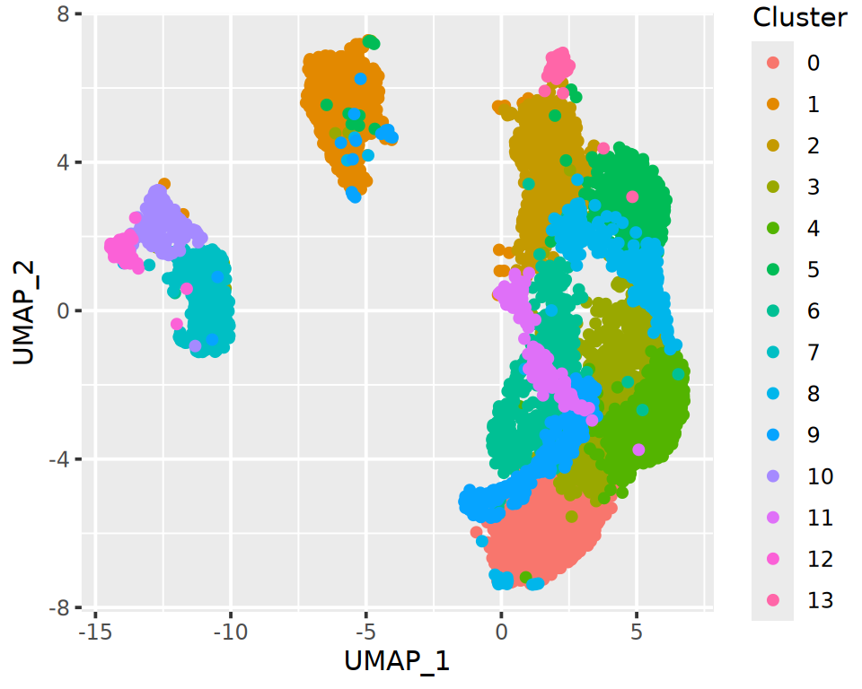

```r
ggplot(sc, aes(x=UMAP_1, y=UMAP_2, color=Cluster)) +
  geom_point()
```

3. Save the plot to a PDF.

```r
pdf("basic_UMAP_plot.pdf")
ggplot(sc, aes(x=UMAP_1, y=UMAP_2, color=Cluster)) +
  geom_point()
dev.off()
```

4. Facet by genotype (`facet_wrap`)

*If you do not see a plot appear, make sure you have run dev.off() above.*

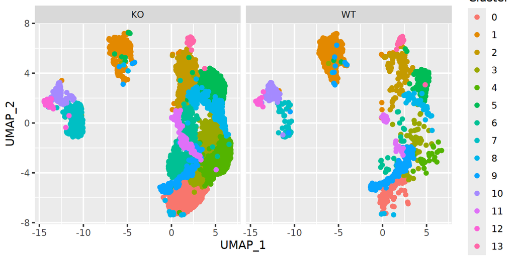

```r
ggplot(sc, aes(x=UMAP_1, y=UMAP_2, color=Cluster)) +
  geom_point() +
  facet_wrap( ~ Genotype)
```

5. Facet by genotype and batch (`facet_grid`)

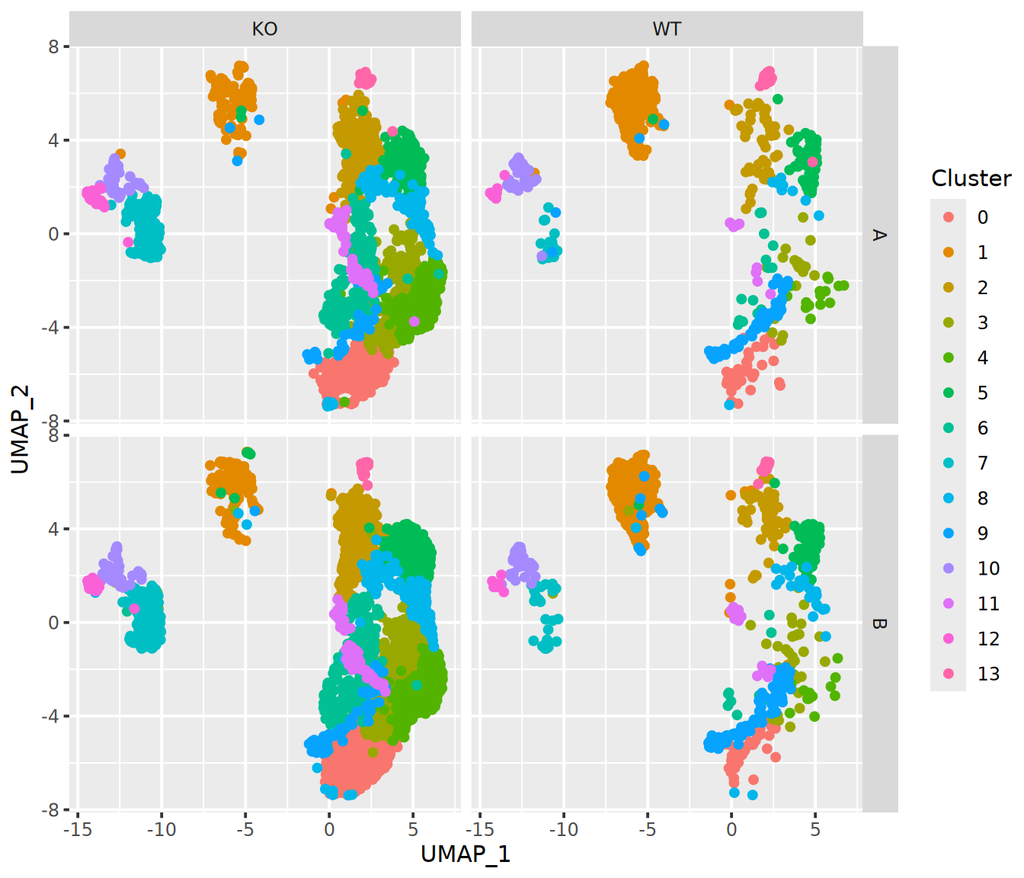

```r
ggplot(sc, aes(x=UMAP_1, y=UMAP_2, color=Cluster)) +
  geom_point() +
  facet_grid( Batch ~ Genotype)
```

### 2.1.3 Box plots and violin plots

These are both ways to plot the distribution of values.

Show the level of Cxcr6 by cluster and genotype * First as a boxplot

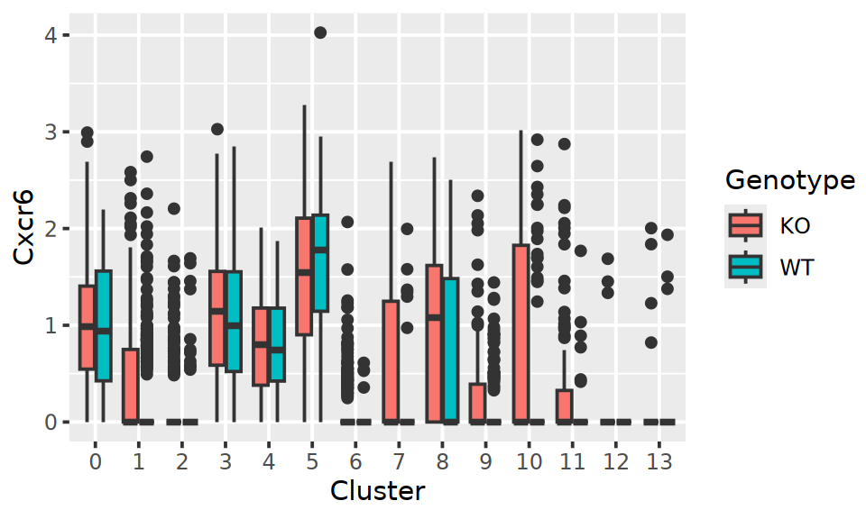

```r
ggplot(sc, aes(x=Cluster, y=Cxcr6, fill=Genotype)) +
  geom_boxplot()
```

- As a violin plot

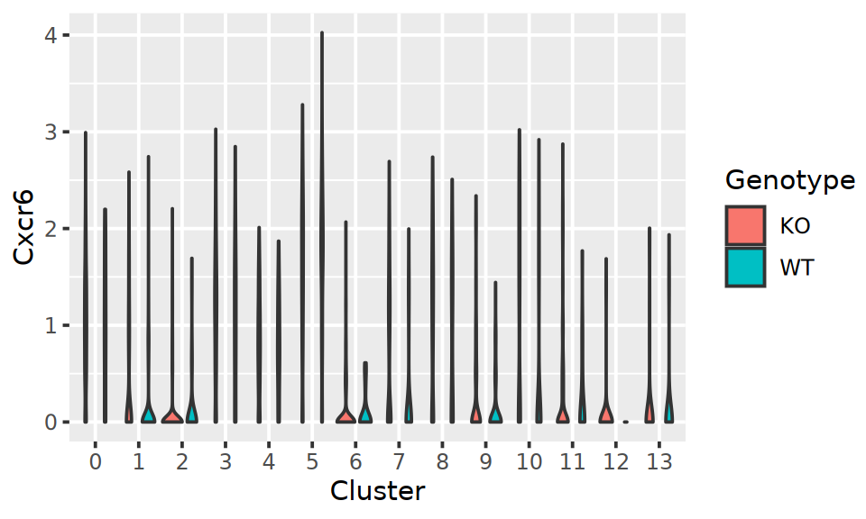

```r
ggplot(sc, aes(x=Cluster, y=Cxcr6, fill=Genotype)) +
  geom_violin()
```

- Same but with using ggplot variables.

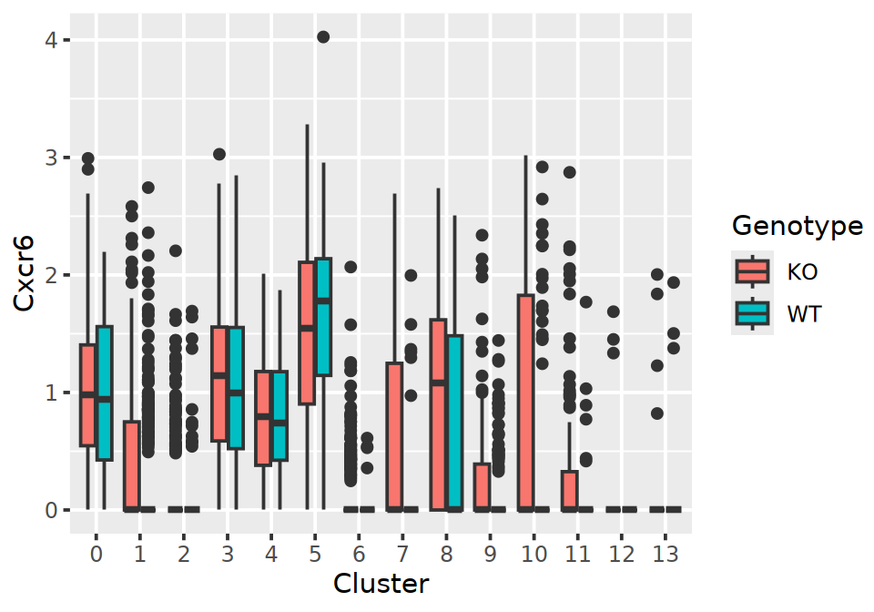

```r
baseplot <- ggplot(sc, aes(x=Cluster, y=Cxcr6, fill=Genotype))
baseplot + geom_boxplot()
```

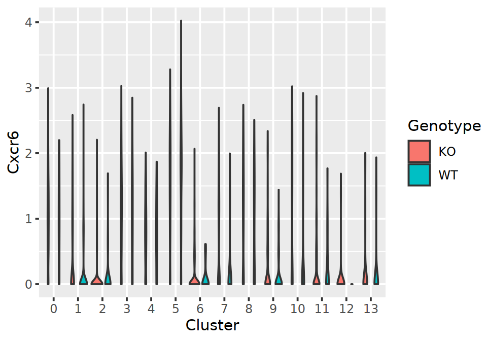

```r
baseplot + geom_violin()
```

### 2.1.4 Bar plots

1. Number of cells per cluster
   - First using `geom_bar()` to have ggplot2 count for you.

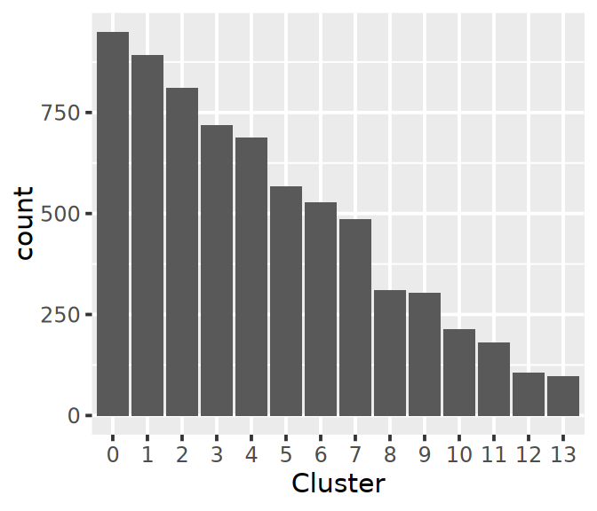

```r
ggplot(sc, aes(x=Cluster)) + geom_bar()
```

- Or do the count first and then use `geom_col()` to plot the values as is.

```r
cluster_counts <- table(sc$Cluster)
cluster_counts
```

```
##
##   0   1   2   3   4   5   6   7   8   9  10  11  12  13
## 949 891 809 718 687 566 526 486 310 303 212 179 106  97
```

```r
cluster_counts_df <- data.frame(cluster_counts)
cluster_counts_df
```

| Var1 | Freq |
| --- | --- |
| 0 | 949 |
| 1 | 891 |
| 2 | 809 |
| 3 | 718 |
| 4 | 687 |
| 5 | 566 |
| 6 | 526 |
| 7 | 486 |
| 8 | 310 |
| 9 | 303 |

[output cut: 4 more lines]

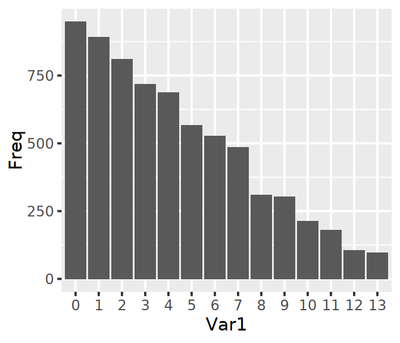

```r
ggplot(cluster_counts_df, aes(x=Var1, y=Freq)) + geom_col()
```

2. Cells per cluster, also with genotype and TCR
   - First as a stacked barplot

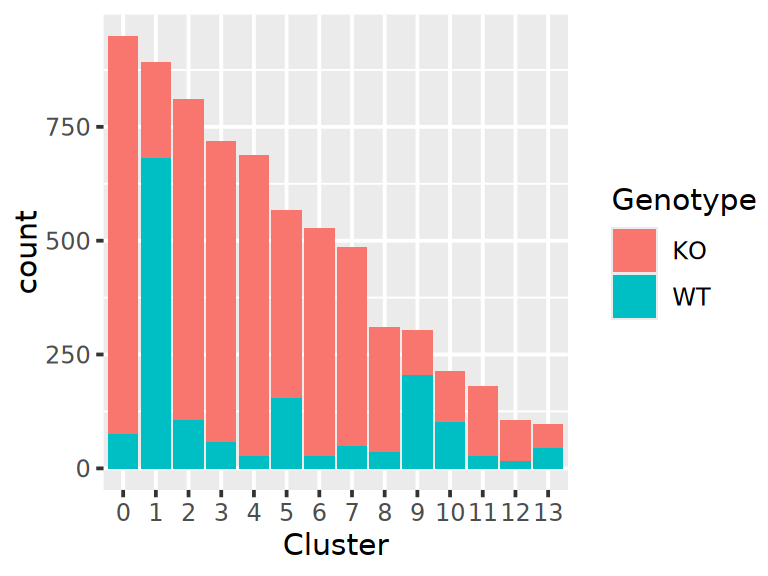

```r
ggplot(sc, aes(x=Cluster, fill=Genotype)) +
  geom_bar()
```

- Side-by-side barplot

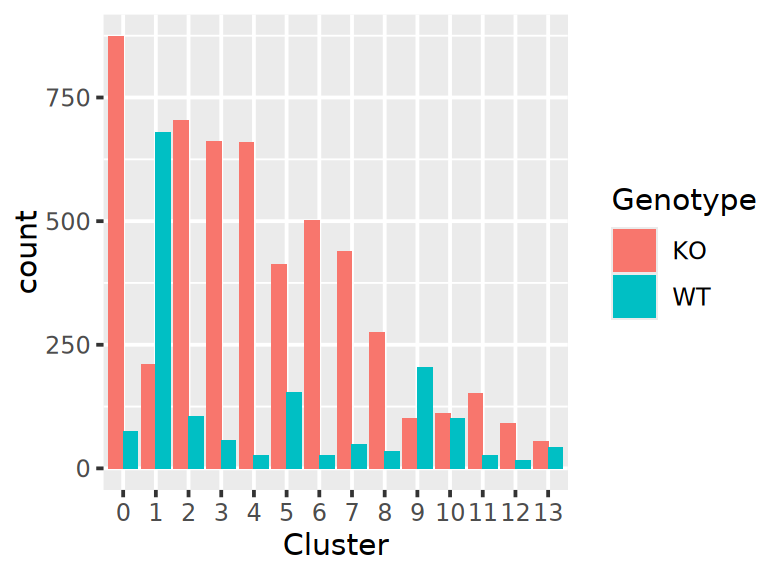

```r
ggplot(sc, aes(x=Cluster, fill=Genotype)) +
  geom_bar(position="dodge")
```

### 2.1.5 **TAKE HOME:** Additional plot examples

**More scatterplots**

1. Update the labels and the theme

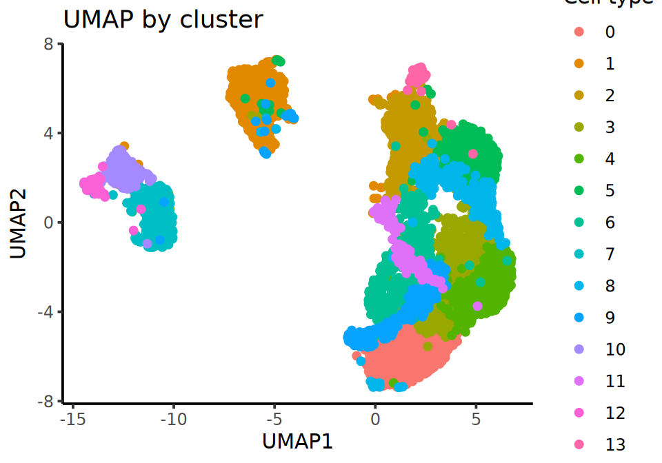

```r
ggplot(sc, aes(x=UMAP_1, y=UMAP_2, color=Cluster)) +
  geom_point() +
  theme_classic() +
  labs(x="UMAP1", y="UMAP2", color="Cell type", title="UMAP by cluster")
```

2. Color by expression of a gene of interest

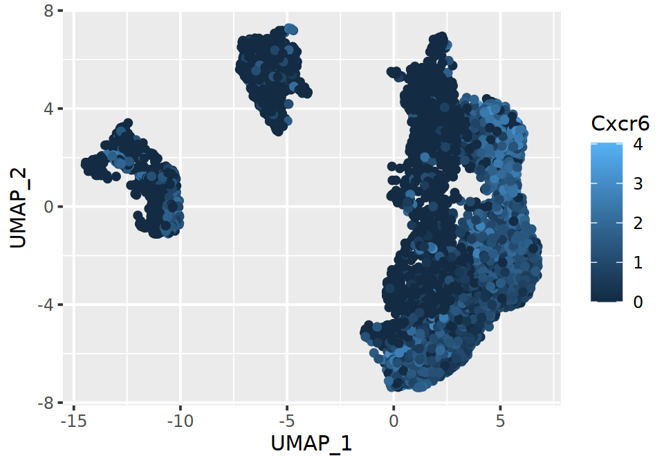

```r
ggplot(sc, aes(x=UMAP_1, y=UMAP_2, color=Cxcr6)) +
  geom_point()
```

- Nicer coloring with viridis palette

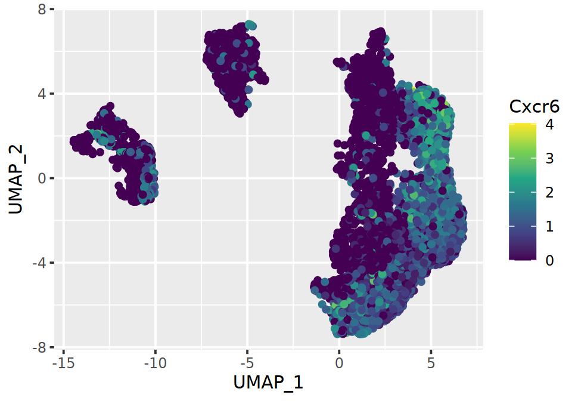

```r
ggplot(sc, aes(x=UMAP_1, y=UMAP_2, color=Cxcr6)) +
  geom_point() +
  scale_color_viridis_c()
```

3. Color by genotype, using a custom color scheme

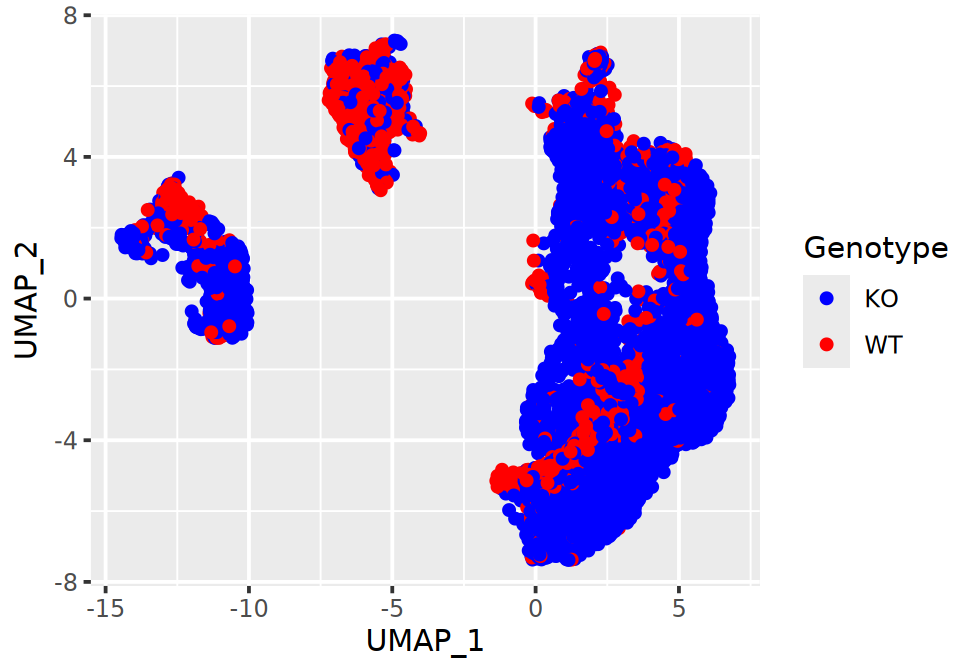

```r
ggplot(sc, aes(x=UMAP_1, y=UMAP_2, color=Genotype)) +
  geom_point() +
  scale_color_manual(values=c("WT"="red","KO"="blue"))
```

**Violin plot for many genes**

This is an example of showing expression for many marker genes over all clusters in a compact visualization.

1. Make a new data frame with just the clusters, and the gene expression levels

```r
gene_expr <- sc[,c(7,10:17)]
head(gene_expr)
```

|  | Cluster | Foxp3 | Ccr2 | Cxcr6 | Tcf7 | Ccr7 | Cxcr5 | Mki67 | Ccnb2 |
| --- | --- | --- | --- | --- | --- | --- | --- | --- | --- |
| cell1 | 0 | 0 | 0.4796434 | 0.0000000 | 0.000000 | 0.000000 | 0 | 1.4054819 | 1.546070 |
| cell2 | 0 | 0 | 0.0000000 | 0.9494970 | 1.092095 | 2.555914 | 0 | 0.3336843 | 1.216873 |
| cell3 | 0 | 0 | 0.0000000 | 0.4524427 | 0.000000 | 0.000000 | 0 | 1.9053081 | 1.718684 |
| cell4 | 0 | 0 | 0.9542333 | 0.9542333 | 0.000000 | 0.000000 | 0 | 2.1953778 | 1.756139 |
| cell5 | 0 | 0 | 0.9711419 | 0.7390628 | 0.000000 | 0.000000 | 0 | 1.3177292 | 1.574619 |
| cell6 | 0 | 0 | 0.0000000 | 1.5057177 | 0.000000 | 0.000000 | 0 | 2.0250317 | 1.683475 |

2. Convert to the “long” format. Load the tidyr library if you haven’t already.

```r
library(tidyr)
gene_expr_long <- pivot_longer(gene_expr, !Cluster)
gene_expr_long
```

| Cluster | name | value |
| --- | --- | --- |
| 0 | Foxp3 | 0.0000000 |
| 0 | Ccr2 | 0.4796434 |
| 0 | Cxcr6 | 0.0000000 |
| 0 | Tcf7 | 0.0000000 |
| 0 | Ccr7 | 0.0000000 |
| 0 | Cxcr5 | 0.0000000 |
| 0 | Mki67 | 1.4054819 |
| 0 | Ccnb2 | 1.5460698 |
| 0 | Foxp3 | 0.0000000 |
| 0 | Ccr2 | 0.0000000 |

[output cut: 9990 more lines]

3. Basic violin plot
   - We are using the faceting to show the different groups, rather than separating along the x-axis

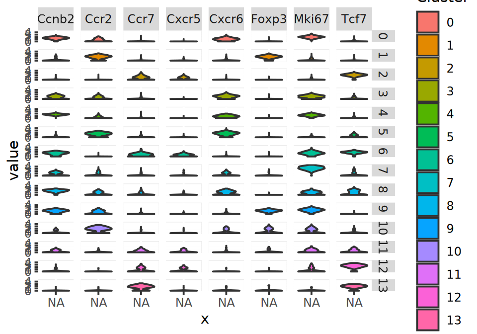

```r
basic_vioplot <- ggplot(gene_expr_long, aes(x=NA,y=value,fill=Cluster)) +
  geom_violin() + facet_grid(Cluster ~ name)
basic_vioplot
```

4. Make it look nicer.
   - `theme_void()` removes the x and y axis tics, labels, and the background grid.
   - `coord_flip()` makes the violins go left-to-right instead of up and down.
   - `guides(fill="none")` turns off the legend for the fill color, as this is redundant with the cluster facet labels.
   - `theme(strip.text.x=element_text(angle=45))` rotates the x-direction facet labels (gene names) by 45 degrees.

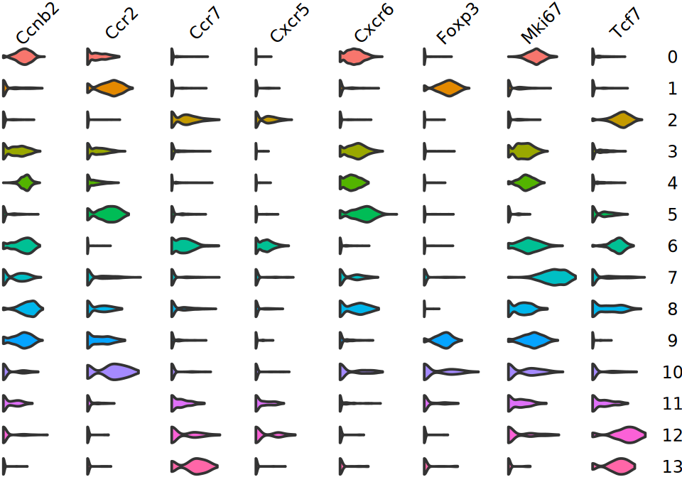

```r
basic_vioplot +
  theme_void() +
  coord_flip() +
  guides(fill="none") +
  theme(strip.text.x=element_text(angle=45))
```

## 2.2 Heatmaps

The test data set are the top 100 differentially expressed genes (DEGs) from an RNA-seq project with 3 groups (Control, disease model 1, disease model 2). The values in this table are log2 CPM (log-scaled normalized expression).

1. Load the *ComplexHeatmap* library and the data.

```r
library(ComplexHeatmap)
degs <- read.delim("http://wd.cri.uic.edu/R/degs.txt",row.names=1)
```

2. Look at the top of the file

```r
head(degs)
```

|  | Control.1 | Control.2 | Control.3 | Control.4 | Model1.10 | Model1.7 | Model1.8 | Model1.9 | Model2.1 | Model2.2 | Model2.3 | Model2.4 |
| --- | --- | --- | --- | --- | --- | --- | --- | --- | --- | --- | --- | --- |
| Trim30a | 2.737756 | 3.119626 | 3.263343 | 3.323339 | 8.118878 | 8.077905 | 8.121378 | 8.596068 | 4.865646 | 4.933805 | 4.628512 | 4.854941 |
| Irf7 | 2.320882 | 2.807611 | 3.251461 | 3.059833 | 8.543963 | 8.363183 | 7.993523 | 8.496866 | 4.388307 | 4.895295 | 4.562431 | 4.264026 |
| Uba7 | 1.482239 | 1.667049 | 1.652447 | 1.733655 | 5.568067 | 5.680392 | 5.705399 | 6.035117 | 2.331715 | 2.740032 | 2.349714 | 2.380767 |
| H2-K1 | 5.579364 | 5.796428 | 6.186799 | 5.853024 | 11.237340 | 10.775320 | 10.574393 | 11.354978 | 7.600480 | 8.036762 | 7.707431 | 7.976884 |
| Rtp4 | 2.555178 | 3.219462 | 3.139870 | 3.223635 | 8.038703 | 7.635932 | 7.871858 | 8.149906 | 5.315020 | 5.485041 | 5.223427 | 4.803613 |
| Gbp7 | 3.349707 | 3.899112 | 4.114419 | 3.693105 | 7.931568 | 8.404947 | 8.234712 | 8.746548 | 5.001805 | 4.991738 | 4.783508 | 4.762849 |

3. Compute z-score expression.
- The `scale()` function will z-score the data by columns. We want to z-score by row. So, we transpose twice.

```r
degs.z <- t(scale(t(degs)))
```

4. Plot a basic heatmap

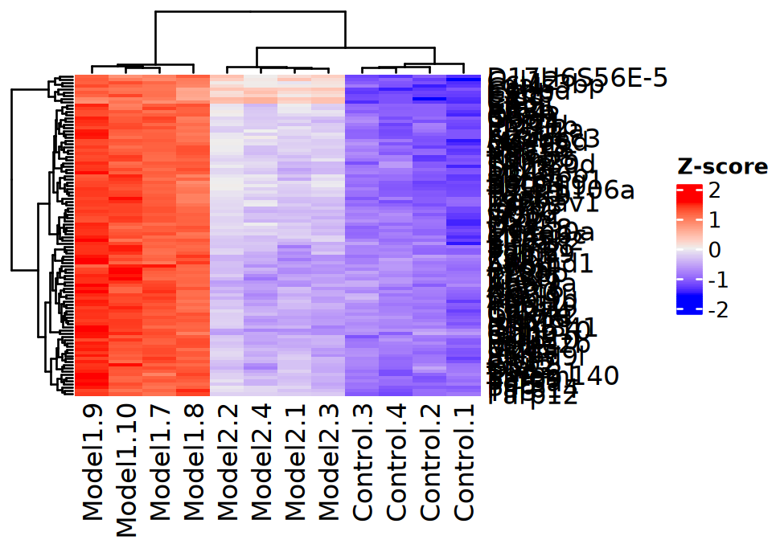

```r
Heatmap(degs.z, name="Z-score")
```

5. Turn off display of row names

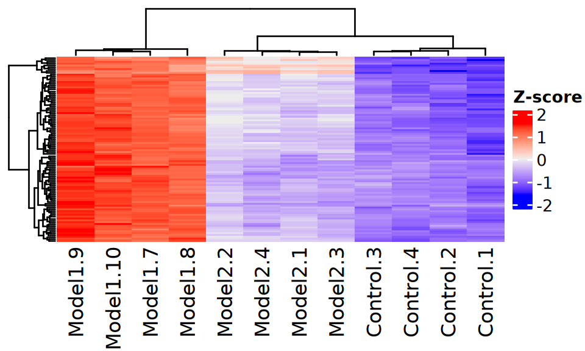

```r
Heatmap(degs.z, name="Z-score", show_row_names=F)
```

### 2.2.1 **TAKE HOME:** Heatmap annotations

Add a color annotation for the groups * First will get the groups for each sample. In these data the group names are included in the sample names. * Then create a named vector with the specified colors for each group with the name as the group/level and the value as the color. * Create a `HeatmapAnnotation` with the group data and the colors. * Finally, generate the heatmap with the annotation on the top.

```r
groups <- gsub("\\.[0-9]*$","",colnames(degs))
groups
```

```
##  [1] "Control" "Control" "Control" "Control" "Model1"  "Model1"  "Model1"
##  [8] "Model1"  "Model2"  "Model2"  "Model2"  "Model2"
```

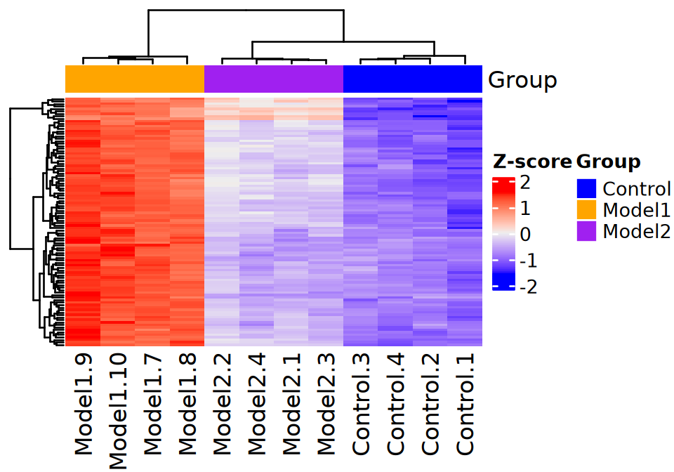

```r
group_colors <- c("Control"="blue","Model1"="orange","Model2"="purple")
column_label <- HeatmapAnnotation(df=data.frame(Group=groups),
  col=list(Group=group_colors), which="column")
Heatmap(degs.z, name="Z-score", show_row_names=F, top_annotation=column_label)
```

## 2.3 PCA

We’ll the same RNA-seq data as above. NOTE: usually you would compute PCA over all genes, rather than just the top ones as in this example.

1. Compute the PCA ordination data using `prcomp()` function.
   - Like scale, prcomp will use the columns as the data (features).
   - In these data, the features (genes) are on the rows. So, we need to transpose

```r
pca <- prcomp(t(degs))
```

2. We can use the `summary()` function to calculate summary statistics on the pca

```r
summary(pca)
```

```
## Importance of components:
##                            PC1     PC2     PC3     PC4     PC5     PC6     PC7
## Standard deviation     20.0719 3.28916 1.09160 1.02606 0.90698 0.80002 0.71785
## Proportion of Variance  0.9614 0.02582 0.00284 0.00251 0.00196 0.00153 0.00123
## Cumulative Proportion   0.9614 0.98720 0.99004 0.99256 0.99452 0.99605 0.99728
##                            PC8     PC9    PC10    PC11      PC12
## Standard deviation     0.69225 0.53578 0.47392 0.38804 2.735e-15
## Proportion of Variance 0.00114 0.00069 0.00054 0.00036 0.000e+00
## Cumulative Proportion  0.99842 0.99910 0.99964 1.00000 1.000e+00
```

3. We can save the summary as an R object (`list`)
   - We can view the available elements in the summary using `names()`.
   - The *importance* element is a `data.frame` with the statistics for each PC axis

```r
pca_stats <- summary(pca)
names(pca_stats)
```

```
## [1] "sdev"       "rotation"   "center"     "scale"      "x"
## [6] "importance"
```

```r
importance <- pca_stats$importance
importance
```

```
##                             PC1      PC2      PC3      PC4       PC5       PC6
## Standard deviation     20.07188 3.289157 1.091597 1.026061 0.9069831 0.8000232
## Proportion of Variance  0.96138 0.025820 0.002840 0.002510 0.0019600 0.0015300
## Cumulative Proportion   0.96138 0.987200 0.990040 0.992560 0.9945200 0.9960500
##                              PC7       PC8       PC9      PC10     PC11
## Standard deviation     0.7178452 0.6922487 0.5357828 0.4739224 0.388043
## Proportion of Variance 0.0012300 0.0011400 0.0006900 0.0005400 0.000360
## Cumulative Proportion  0.9972800 0.9984200 0.9991000 0.9996400 1.000000
##                                PC12
## Standard deviation     2.734799e-15
## Proportion of Variance 0.000000e+00
## Cumulative Proportion  1.000000e+00
```

4. Add the group metadata to the PC coordinates

```r
pca_coords <- data.frame(pca$x)
head(pca_coords)
```

|  | PC1 | PC2 | PC3 | PC4 | PC5 | PC6 | PC7 | PC8 | PC9 | PC10 | PC11 | PC12 |
| --- | --- | --- | --- | --- | --- | --- | --- | --- | --- | --- | --- | --- |
| Control.1 | -23.67698 | -2.794442 | 2.31110480 | -1.3648085 | 0.4438054 | -0.85570762 | -0.02850533 | -0.01697070 | 0.21648596 | 0.19185731 | 0.02881587 | -1.764933e-15 |
| Control.2 | -20.03314 | -3.373580 | 0.67606872 | 1.1575211 | -0.4254660 | 1.87816973 | -0.33852076 | 0.08007903 | -0.07775915 | 0.06163671 | -0.23722235 | 1.465853e-15 |
| Control.3 | -16.82247 | -3.204016 | -1.30218792 | 0.5708611 | -1.3282912 | -1.03289496 | 0.39976621 | 1.04675099 | -0.17083008 | 0.02859881 | 0.16727269 | 4.387976e-16 |
| Control.4 | -18.83471 | -2.725072 | -1.92486798 | -0.4800510 | 1.2789632 | -0.01340913 | 0.11370156 | -1.10825523 | -0.06780109 | -0.36426403 | 0.02586174 | -6.473564e-16 |
| Model1.10 | 26.32187 | -1.415443 | -0.56181960 | -1.8036018 | -0.9394894 | 0.61547431 | -0.84466235 | 0.14953991 | 0.56119315 | -0.19773571 | 0.26217887 | 2.402946e-15 |
| Model1.7 | 24.82256 | -1.117601 | 0.07100481 | 0.2048289 | -0.8632735 | -0.32573886 | 0.43891992 | -1.18114045 | -0.37717808 | 0.84601532 | -0.23130141 | 6.468749e-15 |

```r
pca_coords$Group <- groups
```

5. Create the PCA plot.

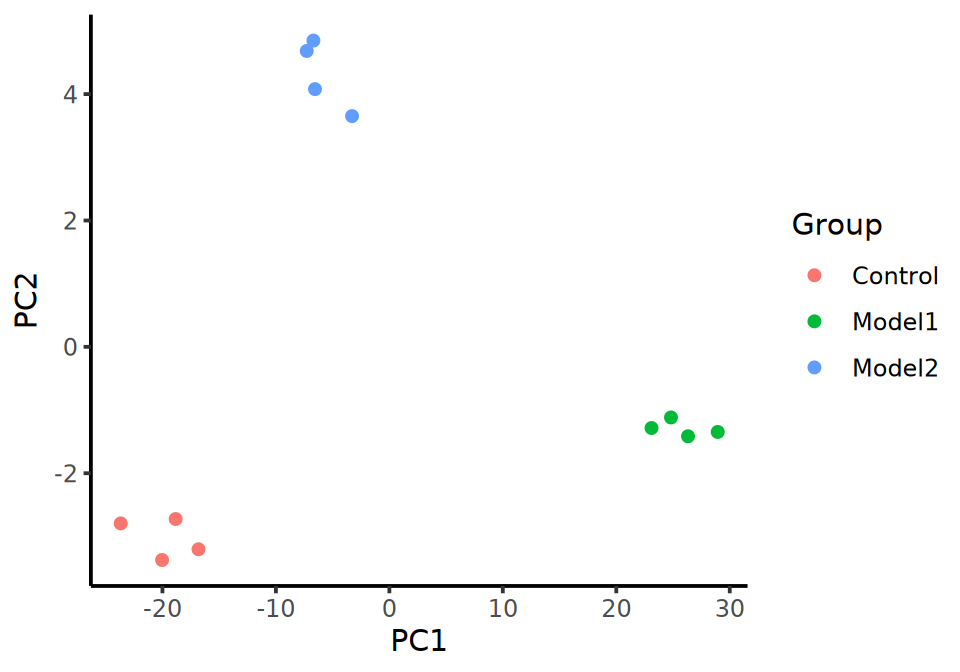

```r
ggplot(data=pca_coords, aes(x=PC1, y=PC2, color=Group)) +
    geom_point() +
    theme_classic()
```

6. Generate a scree plot

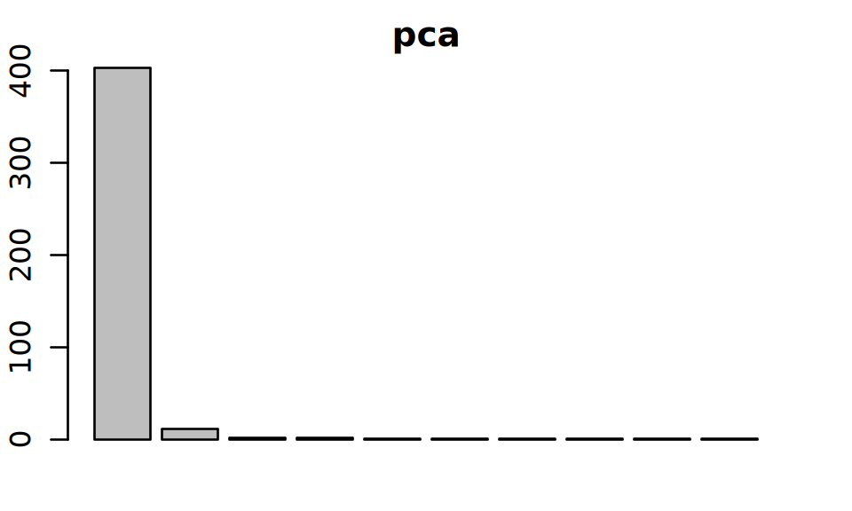

```r
screeplot(pca)
```

NOTE: although all three groups look well-separated in the PC1 vs PC2 plot, note that the biggest differences are with respect to Model1: this is separated along PC1, which explains the vast majority of the variance. This is consistent with what we saw in the heatmap.

### 2.3.1 **TAKE HOME:** Additional PCA plots

1. PCA plot with percent variance

We will add the percent explained variance for each PC in the axis labels. This comes from the importance `data.frame` created in step 3.

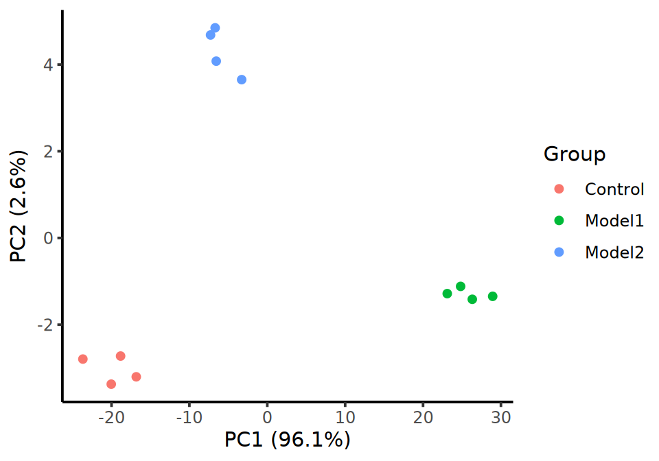

```r
ggplot(data=pca_coords, aes(x=PC1, y=PC2, color=Group)) +
    geom_point() +
    theme_classic() +
    labs(x=paste0("PC1 (", round(100*importance[2,1], 1), "%)"),
         y=paste0("PC2 (", round(100*importance[2,2], 1), "%)"))
```

2. PCA plot with sample labels

For this we’ll use the ggrepel package, which does a good job of fitting text labels into a plot.

Install the package first:

```r
install.packages("ggrepel")
```

Load the *ggrepel* library

```r
library(ggrepel)
```

Add the sample names to our data frame

```r
pca_coords$Sample <- rownames(pca_coords)
```

Create PCA plot, with label aesthetics and `geom_text_repel` layer. set show `legend=F` to avoid the duplicate legend for text colors

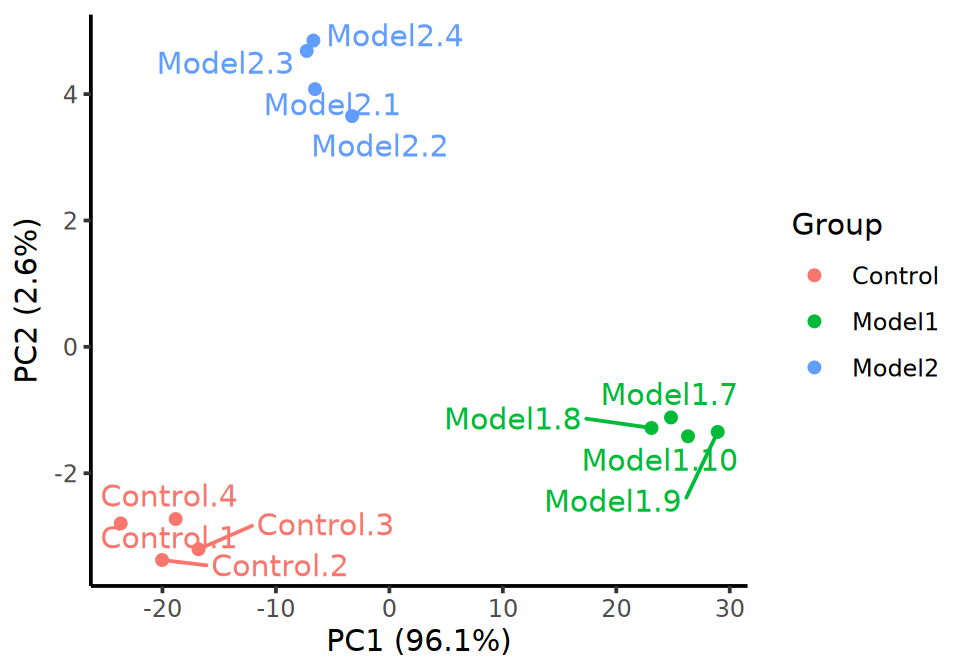

```r
ggplot(data=pca_coords, aes(x=PC1, y=PC2, color=Group, label=Sample)) +
    geom_point() +
    theme_classic() +
    geom_text_repel(show.legend=F) +
    labs(x=paste0("PC1 (", round(100*importance[2,1], 1), "%)"),
         y=paste0("PC2 (", round(100*importance[2,2], 1), "%)"))
```

3. Screeplot using ggplot2 We will need to get the importance into a format for ggplot2.
   - We will create a `data.frame` with each PC axis on a row.
   - The *axis* column will be a factor with the levels by PC order.
   - For simplicity, we are renaming “Standard deviation”, “Proportion of Variance” and “Cumulative Proportion” to “sdev”, “var” and “cum_var”, respectively

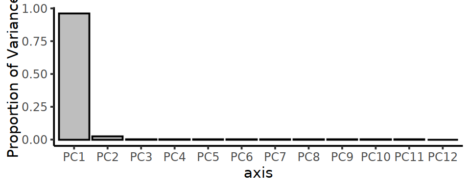

```r
import_df <- as.data.frame(t(importance)) %>%
  rownames_to_column("axis") %>%
  mutate(axis=factor(axis, levels=colnames(importance)))

colnames(import_df)[2:4] <- c("sdev", "var", "cum_var")

ggplot(import_df, aes(x=axis, y=var)) +
  geom_col(fill="gray", color="black") +
  labs(y="Proportion of Variance") +
  theme_classic()
```

## 2.4 Differences between groups (t-test, ANOVA)

### 2.4.1 Data set

We will use the birth weight data from earlier today. Read that back in if needed.

```r
bw_data <- read.delim("https://wd.cri.uic.edu/R/birth_weight.txt")
```

### 2.4.2 t-test and Wilcox test

*Assume we can use a normal distribution to model variance. Check the take-home exercises to see how we can justify that with a Shapiro test.*

Test birth weight vs mother’s smoking status.

1. Make the “smoke” column a factor for easier handling.

```r
bw_data$smoke <- factor(bw_data$smoke)
```

2. Run Student’s t-test
- If one just runs the function, it will print a report

```r
t.test(bwt ~ smoke, data=bw_data)
```

```
##
##  Welch Two Sample t-test
##
## data:  bwt by smoke
## t = 8.6265, df = 941.81, p-value < 2.2e-16
## alternative hypothesis: true difference in means between group 0 and group 1 is not equal to 0
## 95 percent confidence interval:
##   7.158132 11.374153
## sample estimates:
## mean in group 0 mean in group 1
##        123.0853        113.8192
```

- The output can be saved to a variable to extract particular attributes of the results.

```r
ttest_result <- t.test(bwt ~ smoke, data=bw_data)
ttest_result
```

```
##
##  Welch Two Sample t-test
##
## data:  bwt by smoke
## t = 8.6265, df = 941.81, p-value < 2.2e-16
## alternative hypothesis: true difference in means between group 0 and group 1 is not equal to 0
## 95 percent confidence interval:
##   7.158132 11.374153
## sample estimates:
## mean in group 0 mean in group 1
##        123.0853        113.8192
```

```r
ttest_result$p.value
```

```
## [1] 2.656464e-17
```

```r
ttest_result$conf.int
```

```
## [1]  7.158132 11.374153
## attr(,"conf.level")
## [1] 0.95
```

3. Run Wilcox, a.k.a. Mann-Whitney, test

```r
wilcox.test(bwt ~ smoke, data=bw_data)
```

```
##
##  Wilcoxon rank sum test with continuity correction
##
## data:  bwt by smoke
## W = 212970, p-value < 2.2e-16
## alternative hypothesis: true location shift is not equal to 0
```

Like the `t.test()` function, one can save the output to a variable to extract particular attributes.

4. Generate a box plot to visualize.

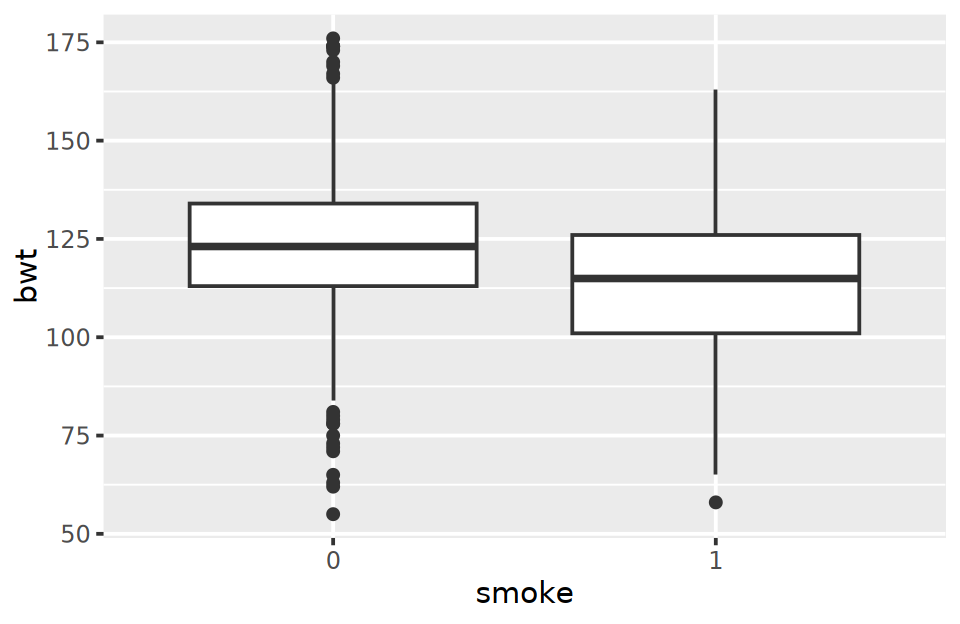

```r
ggplot(bw_data, aes(x=smoke, y=bwt)) +
  geom_boxplot()
```